# World Happiness Report

Connor Moss

2023-07-19

```r
WHR <- read.csv("~/Downloads/Journey to Code/R Stuff/World Happy Report/WHR.csv", header=FALSE, stringsAsFactors=TRUE)
```

The World Happiness Report is published every year in order to see which countries truly are the most happy. Through various synthetic metrics, we look to evaluate which of these factors are most important. In addition, we’ll look to any other trends that might become clear through the analysis.

## Clean the data

First, let’s load the necessary libraries, add some column names, and check for missing values:

```r
library(dplyr)
library(corrplot)
library(ggplot2)
library(FactoMineR)
library(corrr)
library(ggcorrplot)
library(factoextra)
```

```r
#New_WHR eliminates the columns of highs and lows on the box and whisker plots and renames the columns
New_WHR <- WHR[, c(1:3, 6:12)]

colnames(New_WHR)[c(3:10)] <- c("Happiness Score", "Dystopia", "GDP Per Capita", "Social Support",
                                "Healthy Life Expectancy", "Freedom Life Choices",
                                "Generosity", "Perceptions of Corruption")

#Look for missing and duplicated data
sum(is.na(New_WHR))
```

```
## [1] 0
```

```r
sum(duplicated(New_WHR))
```

```
## [1] 0
```

## EDA

We can look at the five number summary of our numeric columns to get an idea of how our data is organized, but first we must turn them into numeric values as they were loaded in as factors

Changing type of the variable introduced a null value into each column so we handle that and then we can look at our five number summary. We can see that the happiness score ranges from 2.4 to 7.8, with an almost identical mean and median of approximately 5.55. Given that Happiness Score is a additive measure of the other metrics in the dataset it seems that Dystopia and GDP Per Capita have the strongest weight in determining Happiness Score, however, we will later be determining the most important variables with Principal Component Analysis.

```r
Clean_WHR <- na.omit(New_WHR)
summary(Clean_WHR[,3:10])
```

```
##  Happiness Score    Dystopia     GDP Per Capita  Social Support
##  Min.   :2.404   Min.   :0.187   Min.   :0.000   Min.   :0.0000
##  1st Qu.:4.889   1st Qu.:1.555   1st Qu.:1.095   1st Qu.:0.7320
##  Median :5.569   Median :1.895   Median :1.446   Median :0.9575
##  Mean   :5.554   Mean   :1.832   Mean   :1.410   Mean   :0.9059
##  3rd Qu.:6.305   3rd Qu.:2.153   3rd Qu.:1.785   3rd Qu.:1.1142
##  Max.   :7.821   Max.   :2.844   Max.   :2.209   Max.   :1.3200
##  Healthy Life Expectancy Freedom Life Choices   Generosity
##  Min.   :0.0000          Min.   :0.0000       Min.   :0.0000
##  1st Qu.:0.4632          1st Qu.:0.4405       1st Qu.:0.0890
##  Median :0.6215          Median :0.5435       Median :0.1325
##  Mean   :0.5862          Mean   :0.5172       Mean   :0.1474
##  3rd Qu.:0.7198          3rd Qu.:0.6260       3rd Qu.:0.1978
##  Max.   :0.9420          Max.   :0.7400       Max.   :0.4680
##  Perceptions of Corruption
##  Min.   :0.00000
##  1st Qu.:0.06825
##  Median :0.11950
##  Mean   :0.15478
##  3rd Qu.:0.19850
##  Max.   :0.58700
```

The correlation matrix allows us to see which variables are most correlated with Happiness Score. Social Support and GDP are most correlated with Happiness as their respective circles are the largest. GDP and Life Expectancy are the most correlated with each other with a respective value of 0.82.

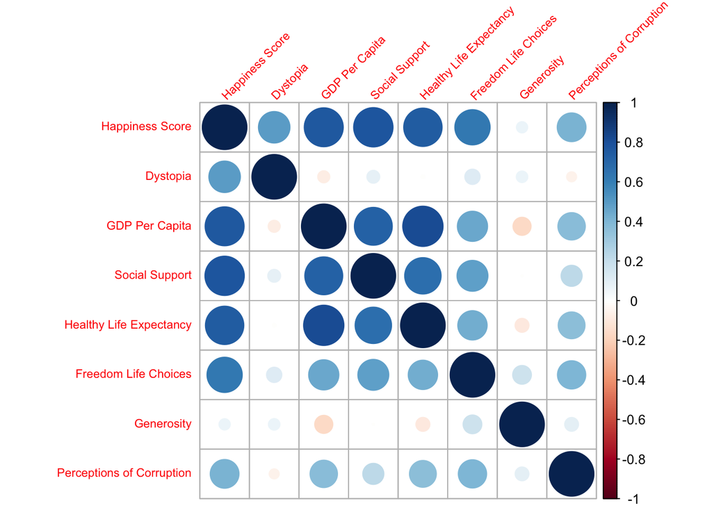

## Principal Component Analysis

Now before we move forward with PCA, we must ensure that our dataset meets the conditions necessary to have applicable results: There are a few conditions that we can assume are met given the nature of PCA: Linearity among the data, Homescedasticity (given that PCA assumes roughly constant variance among all directions), and that the data we are using is all numeric. The other few we can check with some code.

```r
#Non-zero variance
std_data <- apply(Clean_WHR[,3:10], 2, sd)
if (all(std_data > 0)) {
  print("Non-zero variance - Satisfied")
} else {
  print("Non-zero variance - Not satisfied")
}
```

```
## [1] "Non-zero variance - Satisfied"
```

```r
#Covariance Matrix
data_scaled <- scale(Clean_WHR[,3:10], center = TRUE, scale = TRUE)
cov_matrix <- cov(data_scaled)
if (all(is.finite(cov_matrix))) {
  print("Covariance matrix condition - Satisfied")
} else {
  print("Covariance matrix condition - Not satisfied")
}
```

```
## [1] "Covariance matrix condition - Satisfied"
```

I decided to intentionally leave out Happiness Score in the PCA as it is an additive measure of all of the other components.

```r
#Create one more dataframe without Happiness Score
New_WHR_PCA <- New_WHR[,4:10]
#Normalize Datas
New_WHR_PCA<- scale(New_WHR_PCA)
New_WHR_PCA <- na.omit(New_WHR_PCA)
sum(is.na(New_WHR_PCA))
```

```
## [1] 0
```

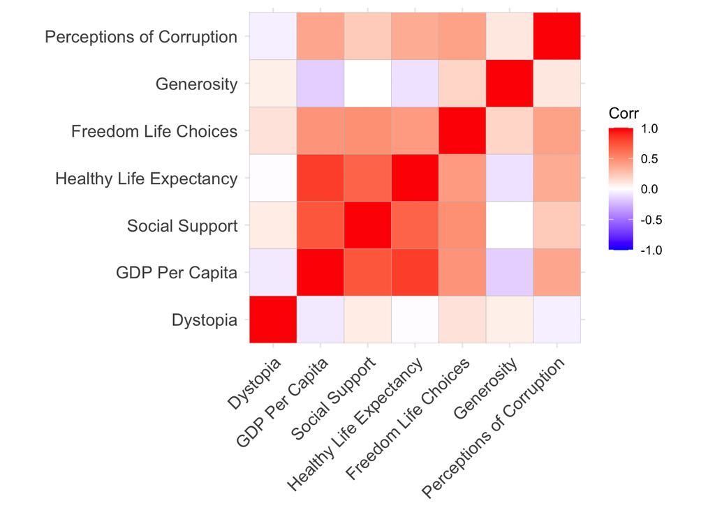

```r
#Better Correlation Plot
corr_matrix <- cor(New_WHR_PCA)
ggcorrplot(corr_matrix)
```

```r
#PCA Results
PCAResult <- princomp(corr_matrix)
summary(PCAResult)
```

```
## Importance of components:
##                           Comp.1    Comp.2     Comp.3     Comp.4     Comp.5
## Standard deviation     0.7386150 0.3893117 0.28092163 0.22328554 0.11428535
## Proportion of Variance 0.6467502 0.1796782 0.09355581 0.05910464 0.01548394
## Cumulative Proportion  0.6467502 0.8264284 0.91998421 0.97908884 0.99457279
##                             Comp.6 Comp.7
## Standard deviation     0.067660985      0
## Proportion of Variance 0.005427215      0
## Cumulative Proportion  1.000000000      1
```

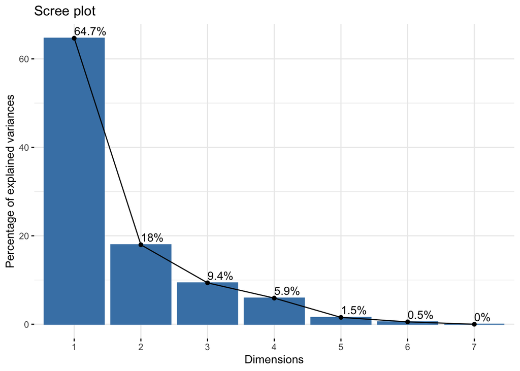

```r
fviz_eig(PCAResult, addlabels = TRUE)
```

```r
PCAResult$loadings[, 1:2]
```

```
##                               Comp.1      Comp.2
## Dystopia                   0.2836643  0.67815921
## GDP Per Capita            -0.5463463  0.05274637
## Social Support            -0.4106066  0.18141518
## Healthy Life Expectancy   -0.4955182  0.07433373
## Freedom Life Choices      -0.1929547 -0.17139113
## Generosity                 0.3717325 -0.46825454
## Perceptions of Corruption -0.1774473 -0.50024364
```

What does it mean? PCA tells us that ’Generosity has a significant role in shaping two distinct aspects of happiness within the dataset. It not only affects the overall happiness level of countries (as represented by component one) but also influences a specific dimension of happiness (as seen in component two).

This seeming to give way to the understood idea that happiness -though represented by a few concrete variables- is still quite complex to understand.

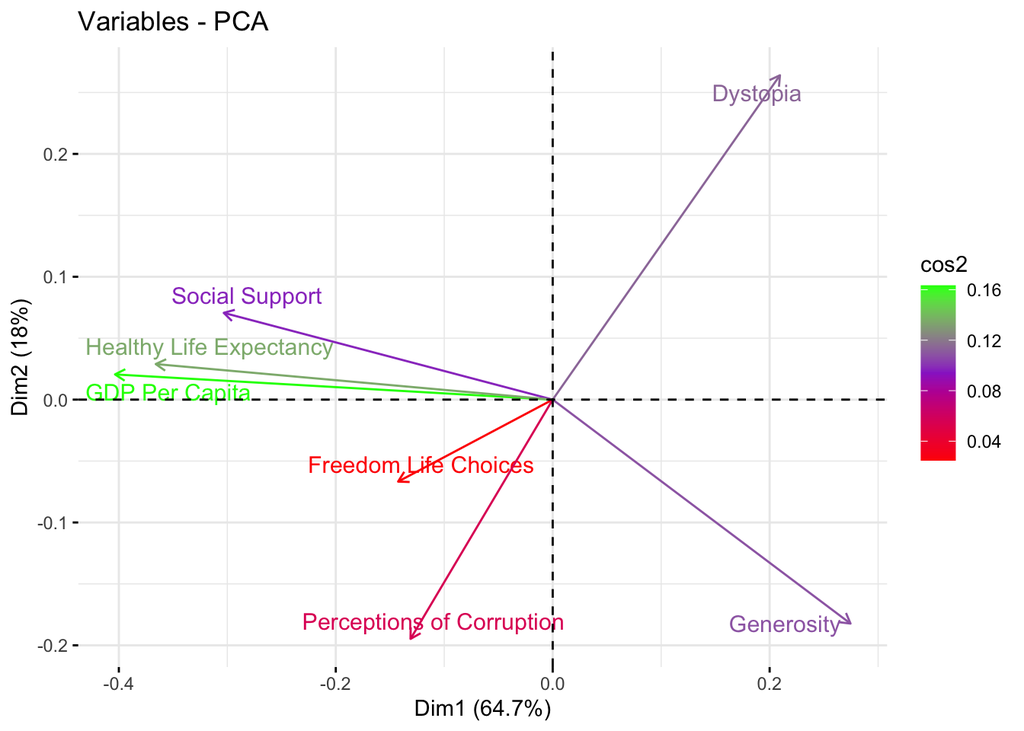

```r
fviz_pca_var(PCAResult, col.var = "cos2",
             gradient.cols = c("red", "darkorchid", "green"),
             repel = TRUE)
```

The last visualization determines how much each variable is represented in a given component. The squared cosine is the numerical value that is computed to achieve this. Though this visual will simplify that understanding as red is associated with a low squared cosine, purple is a medium squared cosine value, and green is a high squared cosine value.

## Linear Regression

```r
all = regsubsets(`Happiness Score` ~ Dystopia +`GDP Per Capita` +`Social Support`+ `Healthy Life Expectancy`+`Freedom Life Choices`+`Generosity`+ `Perceptions of Corruption` ,data=New_WHR)
summaryHH(all)
```

```
##                    model p   rsq      rss adjr2       cp   bic   stderr
## 1                     `S 2 0.605 6.76e+01 0.602 1.08e+08  -126 0.685342
## 2                  D-`PC 3 0.893 1.83e+01 0.891 2.92e+07  -311 0.358049
## 3               D-`PC-`S 4 0.942 9.95e+00 0.941 1.58e+07  -396 0.264709
## 4           D-`PC-`S-`LC 5 0.972 4.80e+00 0.971 7.64e+06  -497 0.184513
## 5       D-`PC-`S-`LC-`oC 6 0.987 2.29e+00 0.986 3.65e+06  -600 0.128001
## 6   D-`PC-`S-`LE-`LC-`oC 7 0.995 8.65e-01 0.995 1.38e+06  -737 0.078895
## 7 D-`PC-`S-`LE-`LC-G-`oC 8 1.000 8.68e-05 1.000 8.00e+00 -2076 0.000793
##
## Model variables with abbreviations
##                                                                                                                                                     model
## `S                                                                                                                                       `Social Support`
## D-`PC                                                                                                                           Dystopia-`GDP Per Capita`
## D-`PC-`S                                                                                                       Dystopia-`GDP Per Capita`-`Social Support`
## D-`PC-`S-`LC                                                                            Dystopia-`GDP Per Capita`-`Social Support`-`Freedom Life Choices`
## D-`PC-`S-`LC-`oC                                            Dystopia-`GDP Per Capita`-`Social Support`-`Freedom Life Choices`-`Perceptions of Corruption`
## D-`PC-`S-`LE-`LC-`oC              Dystopia-`GDP Per Capita`-`Social Support`-`Healthy Life Expectancy`-`Freedom Life Choices`-`Perceptions of Corruption`
## D-`PC-`S-`LE-`LC-G-`oC Dystopia-`GDP Per Capita`-`Social Support`-`Healthy Life Expectancy`-`Freedom Life Choices`-Generosity-`Perceptions of Corruption`
##
## model with largest adjr2
## 7
##
## Number of observations
## 146
```

```r
Pred_model <- lm(`Happiness Score`~Dystopia + `Perceptions of Corruption`, data = New_WHR)
summary(Pred_model)
```

```
##
## Call:
## lm(formula = `Happiness Score` ~ Dystopia + `Perceptions of Corruption`,
##     data = New_WHR)
##
## Residuals:
##     Min      1Q  Median      3Q     Max
## -2.3816 -0.5456  0.2465  0.6235  1.3494
##
## Coefficients:
##                             Estimate Std. Error t value Pr(>|t|)
## (Intercept)                   3.0283     0.2593  11.681  < 2e-16 ***
## Dystopia                      1.0597     0.1268   8.359 5.08e-14 ***
## `Perceptions of Corruption`   3.7746     0.5319   7.097 5.47e-11 ***
## ---
## Signif. codes:  0 '***' 0.001 '**' 0.01 '*' 0.05 '.' 0.1 ' ' 1
##
## Residual standard error: 0.8156 on 143 degrees of freedom
##   (1 observation deleted due to missingness)
## Multiple R-squared:  0.4446, Adjusted R-squared:  0.4368
## F-statistic: 57.24 on 2 and 143 DF,  p-value: < 2.2e-16
```

And from that we can see our linear model that we can test on that unnamed country. But first, let’s check our conditions to make sure we have a functioning and repeatable model: From the four plots we can ensure that our linearity condition is met as the Res vs Fitted plot has no unusual structure and the points are randomly scattered. Our Normal QQ plot checks off our normality condition as many of the points fall on or near the line. We do have a slight probelm on the upper tail which could possibly present a problem, but for the sake of brevity in this short example we are going to ignore it (but note that this could be solved with a transformation). And finally we cann see that other than point 144 which is close, none of the points are outside of Cook’s distance meaning that none of our data is unusual or extreme.

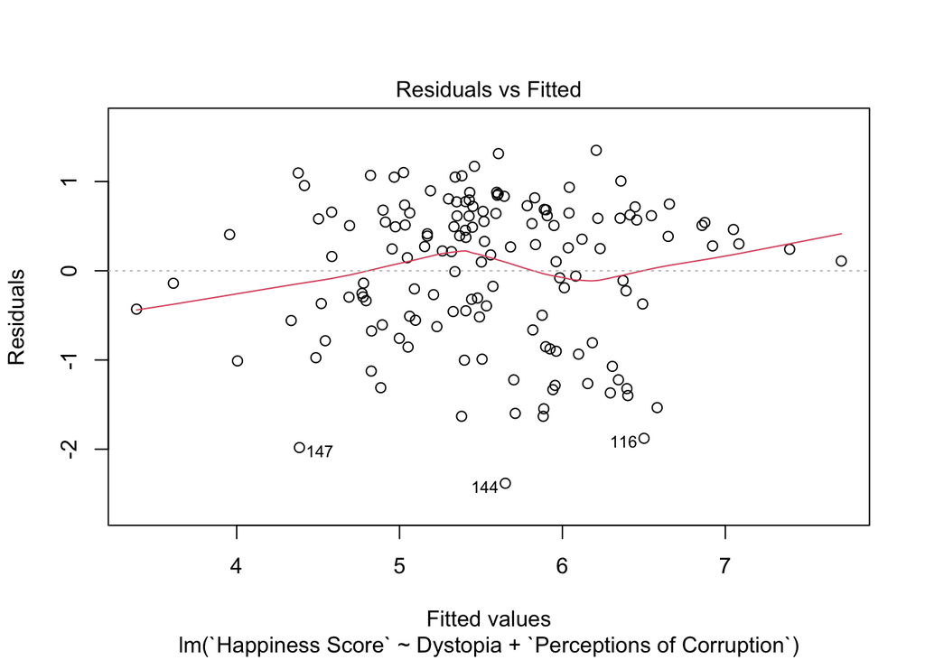

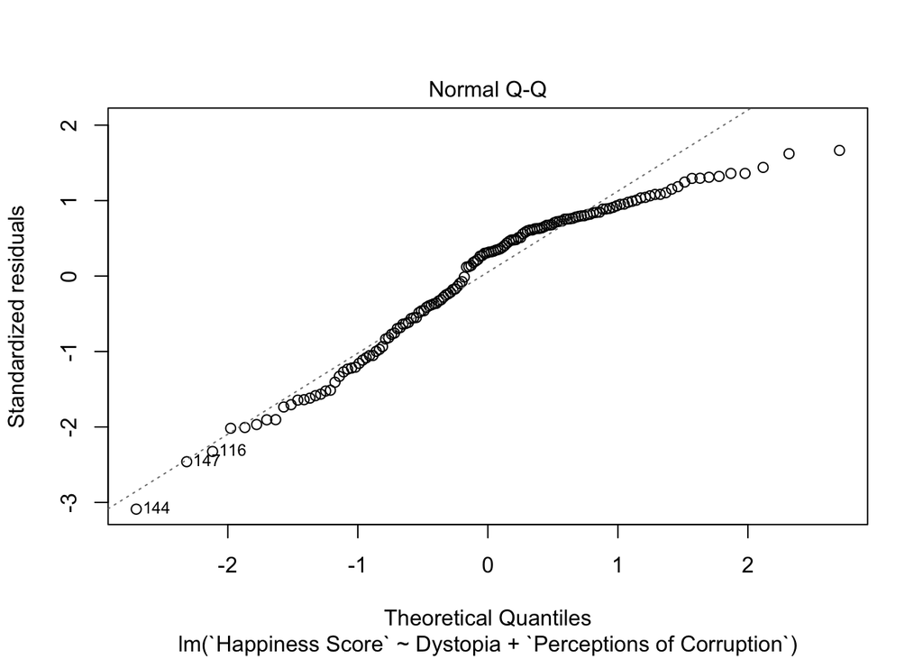

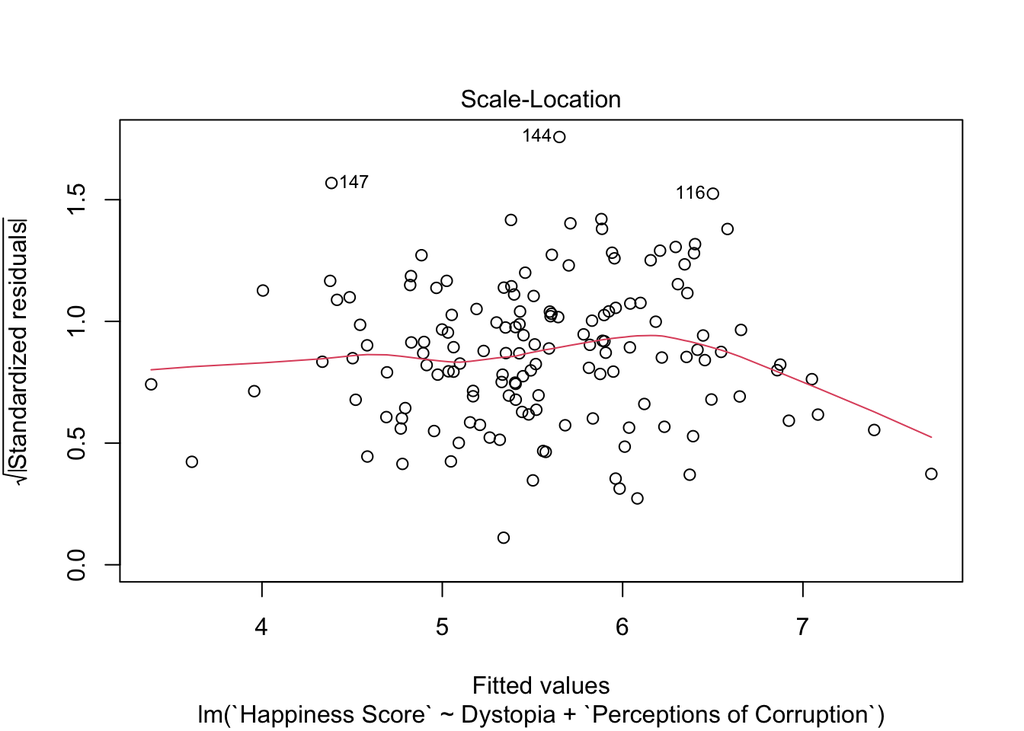

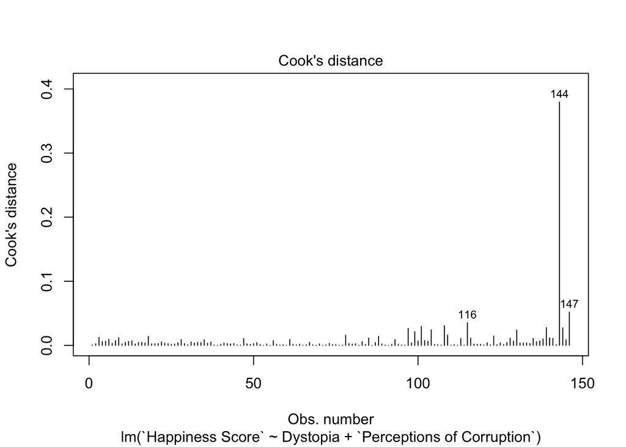

```r
plot(Pred_model, 1:4)
```

And to check how well our model does let’s produce some values for ‘P-value Paradise.’ P-value Paradise has a Dystopia score of 1.883 and a ‘Perception of Corruption’ score of 0.088. It’s a middle of the pack country in terms of the numbers. And given that the mean of the Happiness Score for all of the countries was around 5.5 we should be expecting a number right around there.

```r
3.028 + 1.060*(1.883) + 3.775*(0.088)
```

```
## [1] 5.35618
```

## Conclusion

And with that we can say that our model does a decent job of predicting Happiness Scores of countries with relatively similar scores to the dataset. Much more advanced exploration can be performed in future projects, this was merely an introduction and an opportunity to perform PCA. The next step would most likely be to introduce clustering (k-means or hierarchical) in order to find cultural or regional insights between variables that predict happiness. The other logical next step would be to cross-validate in order to address issues of overfitting in addition to providing a more reliable estimate of the model’s performance with new, unseen data.